# Health and Economic Impact of Severe Weather (US 1950 - 2011)

Randy Armknecht

Friday, July 24, 2015

## Synopis

Over the last 60 years more than $419 Billion in economic damage has occured, the bulk by flooding and hurricanes. More than 154,000 people have been either injured or killed by storms. Given the broad timeframe, and the population of the United States, this number was much lower than anticipated. What follows is the data processing to setup the analysis, some core results to answer the main questions, and then exploratory analysis as a bonus.

## Data Processing

### Preparing the environment

It’s good practice to set the working directory at the start of a project:

```r
setwd("C:/Users/Randy/Documents/Github/Reproducible-Research/storms/")
```

### Loading and Processing the Data

First obtain the data:

```r
# Only need to do this once, commenting out for knitr
#data.url <- 'https://d396qusza40orc.cloudfront.net/repdata/data/StormData.csv.bz2'
#download.file(data.url, destfile="storms.csv.bz2")
```

Now we can load the data we’ve downloaded:

```r
data.raw <- read.csv("storms.csv.bz2")
```

And consider some basic information about it:

```r
dim(data.raw)
```

```
## [1] 902297     37
```

```r
summary(data.raw)
```

```
##     STATE__                  BGN_DATE             BGN_TIME
##  Min.   : 1.0   5/25/2011 0:00:00:  1202   12:00:00 AM: 10163
##  1st Qu.:19.0   4/27/2011 0:00:00:  1193   06:00:00 PM:  7350
##  Median :30.0   6/9/2011 0:00:00 :  1030   04:00:00 PM:  7261
##  Mean   :31.2   5/30/2004 0:00:00:  1016   05:00:00 PM:  6891
##  3rd Qu.:45.0   4/4/2011 0:00:00 :  1009   12:00:00 PM:  6703
##  Max.   :95.0   4/2/2006 0:00:00 :   981   03:00:00 PM:  6700
##                 (Other)          :895866   (Other)    :857229
##    TIME_ZONE          COUNTY           COUNTYNAME         STATE
##  CST    :547493   Min.   :  0.0   JEFFERSON :  7840   TX     : 83728
##  EST    :245558   1st Qu.: 31.0   WASHINGTON:  7603   KS     : 53440
##  MST    : 68390   Median : 75.0   JACKSON   :  6660   OK     : 46802
##  PST    : 28302   Mean   :100.6   FRANKLIN  :  6256   MO     : 35648
##  AST    :  6360   3rd Qu.:131.0   LINCOLN   :  5937   IA     : 31069
##  HST    :  2563   Max.   :873.0   MADISON   :  5632   NE     : 30271
##  (Other):  3631                   (Other)   :862369   (Other):621339
##                EVTYPE         BGN_RANGE           BGN_AZI
##  HAIL             :288661   Min.   :   0.000          :547332
##  TSTM WIND        :219940   1st Qu.:   0.000   N      : 86752
##  THUNDERSTORM WIND: 82563   Median :   0.000   W      : 38446
##  TORNADO          : 60652   Mean   :   1.484   S      : 37558
##  FLASH FLOOD      : 54277   3rd Qu.:   1.000   E      : 33178
##  FLOOD            : 25326   Max.   :3749.000   NW     : 24041
##  (Other)          :170878                      (Other):134990
##          BGN_LOCATI                  END_DATE             END_TIME
##               :287743                    :243411              :238978
##  COUNTYWIDE   : 19680   4/27/2011 0:00:00:  1214   06:00:00 PM:  9802
##  Countywide   :   993   5/25/2011 0:00:00:  1196   05:00:00 PM:  8314
##  SPRINGFIELD  :   843   6/9/2011 0:00:00 :  1021   04:00:00 PM:  8104
##  SOUTH PORTION:   810   4/4/2011 0:00:00 :  1007   12:00:00 PM:  7483
##  NORTH PORTION:   784   5/30/2004 0:00:00:   998   11:59:00 PM:  7184
##  (Other)      :591444   (Other)          :653450   (Other)    :622432
##    COUNTY_END COUNTYENDN       END_RANGE           END_AZI
##  Min.   :0    Mode:logical   Min.   :  0.0000          :724837
##  1st Qu.:0    NA's:902297    1st Qu.:  0.0000   N      : 28082
##  Median :0                   Median :  0.0000   S      : 22510
##  Mean   :0                   Mean   :  0.9862   W      : 20119
##  3rd Qu.:0                   3rd Qu.:  0.0000   E      : 20047
##  Max.   :0                   Max.   :925.0000   NE     : 14606
##                                                 (Other): 72096
```

[output cut: 41 more lines]

```
##  Min.   :   0   Min.   :-14451   Min.   :   0   Min.   :-14455
##  1st Qu.:2802   1st Qu.:  7247   1st Qu.:   0   1st Qu.:     0
##  Median :3540   Median :  8707   Median :   0   Median :     0
##  Mean   :2875   Mean   :  6940   Mean   :1452   Mean   :  3509
##  3rd Qu.:4019   3rd Qu.:  9605   3rd Qu.:3549   3rd Qu.:  8735
##  Max.   :9706   Max.   : 17124   Max.   :9706   Max.   :106220
##  NA's   :47                      NA's   :40
##                                            REMARKS           REFNUM
##                                                :287433   Min.   :     1
##                                                : 24013   1st Qu.:225575
##  Trees down.\n                                 :  1110   Median :451149
##  Several trees were blown down.\n              :   568   Mean   :451149
##  Trees were downed.\n                          :   446   3rd Qu.:676723
##  Large trees and power lines were blown down.\n:   432   Max.   :902297
##  (Other)                                       :588295
```

```r
head(data.raw)
```

```
##   STATE__           BGN_DATE BGN_TIME TIME_ZONE COUNTY COUNTYNAME STATE
## 1       1  4/18/1950 0:00:00     0130       CST     97     MOBILE    AL
## 2       1  4/18/1950 0:00:00     0145       CST      3    BALDWIN    AL
## 3       1  2/20/1951 0:00:00     1600       CST     57    FAYETTE    AL
## 4       1   6/8/1951 0:00:00     0900       CST     89    MADISON    AL
## 5       1 11/15/1951 0:00:00     1500       CST     43    CULLMAN    AL
## 6       1 11/15/1951 0:00:00     2000       CST     77 LAUDERDALE    AL
##    EVTYPE BGN_RANGE BGN_AZI BGN_LOCATI END_DATE END_TIME COUNTY_END
## 1 TORNADO         0                                               0
## 2 TORNADO         0                                               0
## 3 TORNADO         0                                               0
## 4 TORNADO         0                                               0
## 5 TORNADO         0                                               0
## 6 TORNADO         0                                               0
##   COUNTYENDN END_RANGE END_AZI END_LOCATI LENGTH WIDTH F MAG FATALITIES
```

[output cut: 20 more lines]

Create a dataset that is focused on health information:

```r
library(dplyr)
data.slim.health <- select(data.raw, BGN_DATE, STATE, EVTYPE, FATALITIES, INJURIES)

health <- group_by(data.slim.health, EVTYPE)
health.sum <- summarise(health,
    count = n(),
    fatalities = sum(FATALITIES),
    injuries = sum(INJURIES),
    f_or_i = fatalities + injuries,
    i_per_event = injuries / count,
    f_per_event = fatalities / count,
    if_per_event = (injuries+fatalities)/count)
```

Create a dataset that is focused on economic information:

```r
# Limit the fields we need
data.slim.econ <- select(data.raw, BGN_DATE, STATE, EVTYPE, PROPDMG, PROPDMGEXP, CROPDMG, CROPDMGEXP)

# Groupd by Event Type
econ <- group_by(data.slim.econ, EVTYPE)

# Crop Damage
conly <- filter(econ, CROPDMG > 0)

# We need to create actual dollar values
conly <- mutate(conly, cm = ifelse(CROPDMGEXP == "K", 1000,
                            ifelse(CROPDMGEXP == "M", 1000000,
                            ifelse(CROPDMGEXP == "m", 1000000,
                            ifelse(CROPDMGEXP == "B", 1000000000, 1)))))
conly <- mutate(conly, cvalue = cm*CROPDMG)

# Property Damage
ponly <- filter(econ, PROPDMG > 0)

# We need to create actual dollar values
ponly <- mutate(ponly, pm = ifelse(PROPDMGEXP == "K", 1000,
                            ifelse(PROPDMGEXP == "M", 1000000,
                            ifelse(PROPDMGEXP == "m", 1000000,
                            ifelse(PROPDMGEXP == "B", 1000000000, 1)))))
ponly <- mutate(ponly, pvalue = pm*PROPDMG)
```

## Results

### Across the United States, which types of events are most harmful with respect to population health?

We can see that Hurricane/Typhoon and Extreme Heat have traditionally caused the greatest impact on population health on a per event basis. In terms of total impact, Tornados have had the greatest affect on population health. The below chart is logrithmic due to the volume of people impacted by Tornados.

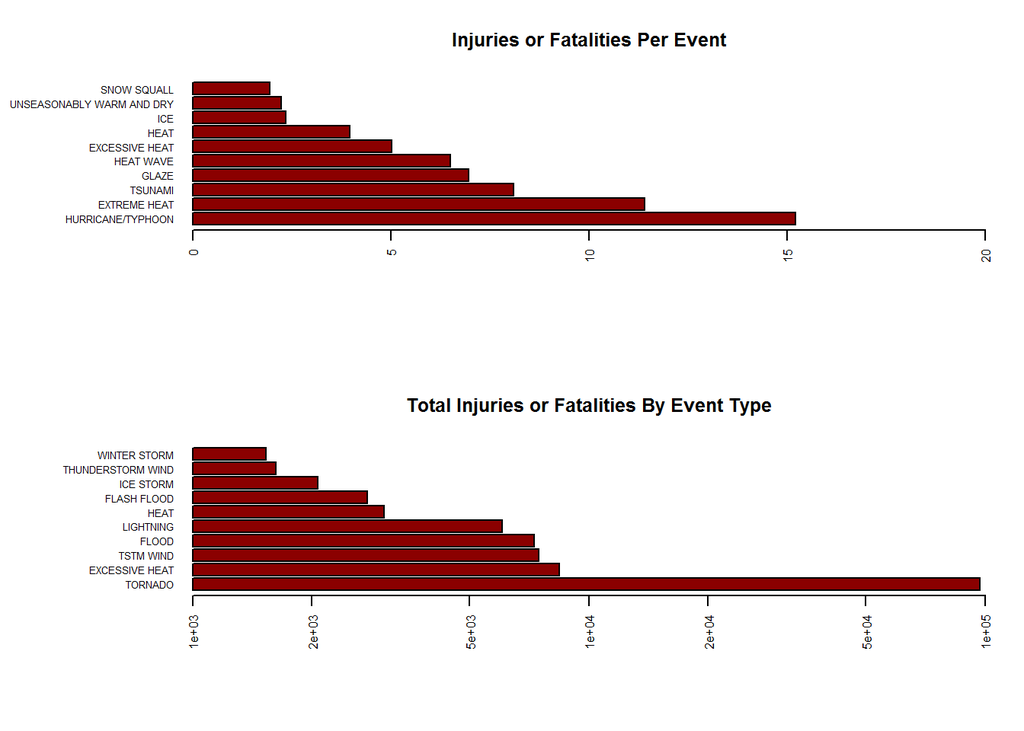

```r
layout(matrix(c(1,1,2,2)))
tmp <- arrange(filter(health.sum, count > 10), desc(if_per_event))[1:10,]
par(las=2) # Make Label Perpendicular to Axis
par(mar=c(7,10,4,2)) # Adjust Y Margin
barplot(tmp$if_per_event,
        names.arg=tmp$EVTYPE,
        horiz=TRUE,
        cex.names=0.6,
        cex.axis=0.8,
        xlim=c(0,20),
        col="Dark Red",
        main="Injuries or Fatalities Per Event")

tmp <- arrange(filter(health.sum, count > 10), desc(f_or_i))[1:10,]
par(las=2) # Make Label Perpendicular to Axis
par(mar=c(7,10,4,2)) # Adjust Y Margin
barplot(tmp$f_or_i,
        names.arg=tmp$EVTYPE,
        horiz=TRUE,
        cex.names=0.6,
        cex.axis=0.8,
        log="x",
        xlim=c(1000,100000),
        col="Dark Red",
        main="Total Injuries or Fatalities By Event Type")
```

### Across the United States, which types of events have the greatest economic impact?

In terms of crop damage, Drought has the greatest impact at nearly $14 Billion in total damages in the data set. In terms of property damage, Flood has the greatest impact at over $144 Billion in total damages in the data set.

```r
layout(matrix(c(1,1,2,2)))
# Crop Damages
tmp <- arrange(summarise(conly, TCD=sum(cvalue)), desc(TCD))[1:10,]
par(las=2) # Make Label Perpendicular to Axis
par(mar=c(7,10,4,2)) # Adjust Y Margin
barplot(tmp$TCD, names.arg=tmp$EVTYPE,
        horiz=TRUE, cex.names = 0.6, cex.axis = 0.8,
        xlim=c(0, 1.5e+10), col="Dark Red", main="Crop Damage by Event Type")
tmp
```

```
## Source: local data frame [10 x 2]
##
##               EVTYPE         TCD
## 1            DROUGHT 13972566000
## 2              FLOOD  5661968450
## 3        RIVER FLOOD  5029459000
## 4          ICE STORM  5022113500
## 5               HAIL  3025537890
## 6          HURRICANE  2741910000
## 7  HURRICANE/TYPHOON  2607872800
## 8        FLASH FLOOD  1421317100
## 9       EXTREME COLD  1292973000
## 10      FROST/FREEZE  1094086000
```

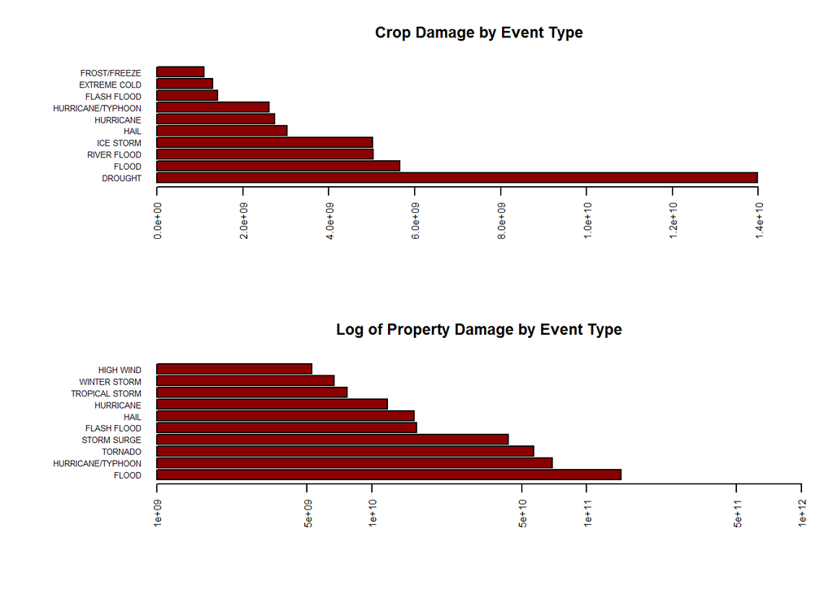

```r
# Property Damages
tmp <- arrange(summarise(ponly, TPD=sum(pvalue)), desc(TPD))[1:10,]
par(las=2) # Make Label Perpendicular to Axis
par(mar=c(7,10,4,2)) # Adjust Y Margin
barplot(tmp$TPD, names.arg=tmp$EVTYPE,
        horiz=TRUE, cex.names = 0.6, cex.axis = 0.8, log="x",
        xlim=c(1.0e+09, 1.0e+12), col="Dark Red", main="Log of Property Damage by Event Type")
```

```r
tmp
```

```
## Source: local data frame [10 x 2]
##
##               EVTYPE          TPD
## 1              FLOOD 144657709807
## 2  HURRICANE/TYPHOON  69305840000
## 3            TORNADO  56937160779
## 4        STORM SURGE  43323536000
## 5        FLASH FLOOD  16140812067
## 6               HAIL  15732267048
## 7          HURRICANE  11868319010
## 8     TROPICAL STORM   7703890550
## 9       WINTER STORM   6688497251
## 10         HIGH WIND   5270046295
```

## Data Exploration

### Health Exploration

Consider various information about the event types impact on population health, per event:

```r
# Events with the greatest number of injuries per event
arrange(health.sum, desc(i_per_event))[1:10,]
```

```
## Source: local data frame [10 x 8]
##
##                     EVTYPE count fatalities injuries f_or_i i_per_event
## 1                Heat Wave     1          0       70     70    70.00000
## 2    TROPICAL STORM GORDON     1          8       43     51    43.00000
## 3               WILD FIRES     4          3      150    153    37.50000
## 4            THUNDERSTORMW     1          0       27     27    27.00000
## 5       HIGH WIND AND SEAS     1          3       20     23    20.00000
## 6          SNOW/HIGH WINDS     2          0       36     36    18.00000
## 7          GLAZE/ICE STORM     1          0       15     15    15.00000
## 8        HEAT WAVE DROUGHT     1          4       15     19    15.00000
## 9  WINTER STORM HIGH WINDS     1          1       15     16    15.00000
## 10       HURRICANE/TYPHOON    88         64     1275   1339    14.48864
## Variables not shown: f_per_event (dbl), if_per_event (dbl)
```

```r
# Events with the greatest number of fatalities per event
arrange(health.sum, desc(f_per_event))[1:10,]
```

```
## Source: local data frame [10 x 8]
##
##                        EVTYPE count fatalities injuries f_or_i i_per_event
## 1  TORNADOES, TSTM WIND, HAIL     1         25        0     25    0.000000
## 2               COLD AND SNOW     1         14        0     14    0.000000
## 3       TROPICAL STORM GORDON     1          8       43     51   43.000000
## 4       RECORD/EXCESSIVE HEAT     3         17        0     17    0.000000
## 5                EXTREME HEAT    22         96      155    251    7.045455
## 6           HEAT WAVE DROUGHT     1          4       15     19   15.000000
## 7              HIGH WIND/SEAS     1          4        0      4    0.000000
## 8               MARINE MISHAP     2          7        5     12    2.500000
## 9               WINTER STORMS     3         10       17     27    5.666667
## 10        Heavy surf and wind     1          3        0      3    0.000000
## Variables not shown: f_per_event (dbl), if_per_event (dbl)
```

```r
# Again, but only Event Types that have occured at least 10 times
arrange(filter(health.sum, count > 10), desc(i_per_event))[1:10,]
```

```
## Source: local data frame [10 x 8]
##
##               EVTYPE count fatalities injuries f_or_i i_per_event
## 1  HURRICANE/TYPHOON    88         64     1275   1339   14.488636
## 2       EXTREME HEAT    22         96      155    251    7.045455
## 3              GLAZE    32          7      216    223    6.750000
## 4            TSUNAMI    20         33      129    162    6.450000
## 5          HEAT WAVE    74        172      309    481    4.175676
## 6     EXCESSIVE HEAT  1678       1903     6525   8428    3.888558
## 7               HEAT   767        937     2100   3037    2.737940
## 8                ICE    61          6      137    143    2.245902
## 9        SNOW SQUALL    19          2       35     37    1.842105
## 10         BLACK ICE    14          1       24     25    1.714286
## Variables not shown: f_per_event (dbl), if_per_event (dbl)
```

```r
arrange(filter(health.sum, count > 10), desc(f_per_event))[1:10,]
```

```
## Source: local data frame [10 x 8]
##
##                       EVTYPE count fatalities injuries f_or_i i_per_event
## 1               EXTREME HEAT    22         96      155    251   7.0454545
## 2                  HEAT WAVE    74        172      309    481   4.1756757
## 3  UNSEASONABLY WARM AND DRY    13         29        0     29   0.0000000
## 4                    TSUNAMI    20         33      129    162   6.4500000
## 5                       HEAT   767        937     2100   3037   2.7379400
## 6             EXCESSIVE HEAT  1678       1903     6525   8428   3.8885578
## 7                RIP CURRENT   470        368      232    600   0.4936170
## 8          HURRICANE/TYPHOON    88         64     1275   1339  14.4886364
## 9               RIP CURRENTS   304        204      297    501   0.9769737
## 10         FLASH FLOOD/FLOOD    22         14        0     14   0.0000000
## Variables not shown: f_per_event (dbl), if_per_event (dbl)
```

```r
# Let's consider both fatalities and injuries, as both impact population health
arrange(filter(health.sum, count > 10), desc(if_per_event))[1:10,]
```

```
## Source: local data frame [10 x 8]
##
##                       EVTYPE count fatalities injuries f_or_i i_per_event
## 1          HURRICANE/TYPHOON    88         64     1275   1339   14.488636
## 2               EXTREME HEAT    22         96      155    251    7.045455
## 3                    TSUNAMI    20         33      129    162    6.450000
## 4                      GLAZE    32          7      216    223    6.750000
## 5                  HEAT WAVE    74        172      309    481    4.175676
## 6             EXCESSIVE HEAT  1678       1903     6525   8428    3.888558
## 7                       HEAT   767        937     2100   3037    2.737940
## 8                        ICE    61          6      137    143    2.245902
## 9  UNSEASONABLY WARM AND DRY    13         29        0     29    0.000000
## 10               SNOW SQUALL    19          2       35     37    1.842105
## Variables not shown: f_per_event (dbl), if_per_event (dbl)
```

Consider various information about the event types impact on population health, in total:

```r
# Events with the greatest number of injuries
arrange(health.sum, desc(injuries))[1:10,]
```

```
## Source: local data frame [10 x 8]
##
##               EVTYPE  count fatalities injuries f_or_i i_per_event
## 1            TORNADO  60652       5633    91346  96979 1.506067401
## 2          TSTM WIND 219940        504     6957   7461 0.031631354
## 3              FLOOD  25326        470     6789   7259 0.268064440
## 4     EXCESSIVE HEAT   1678       1903     6525   8428 3.888557807
## 5          LIGHTNING  15754        816     5230   6046 0.331979180
## 6               HEAT    767        937     2100   3037 2.737940026
## 7          ICE STORM   2006         89     1975   2064 0.984546361
## 8        FLASH FLOOD  54277        978     1777   2755 0.032739466
## 9  THUNDERSTORM WIND  82563        133     1488   1621 0.018022601
## 10              HAIL 288661         15     1361   1376 0.004714873
## Variables not shown: f_per_event (dbl), if_per_event (dbl)
```

```r
# Events with the greatest number of fatalities per event
arrange(health.sum, desc(fatalities))[1:10,]
```

```
## Source: local data frame [10 x 8]
##
##            EVTYPE  count fatalities injuries f_or_i i_per_event
## 1         TORNADO  60652       5633    91346  96979  1.50606740
## 2  EXCESSIVE HEAT   1678       1903     6525   8428  3.88855781
## 3     FLASH FLOOD  54277        978     1777   2755  0.03273947
## 4            HEAT    767        937     2100   3037  2.73794003
## 5       LIGHTNING  15754        816     5230   6046  0.33197918
## 6       TSTM WIND 219940        504     6957   7461  0.03163135
## 7           FLOOD  25326        470     6789   7259  0.26806444
## 8     RIP CURRENT    470        368      232    600  0.49361702
## 9       HIGH WIND  20212        248     1137   1385  0.05625371
## 10      AVALANCHE    386        224      170    394  0.44041451
## Variables not shown: f_per_event (dbl), if_per_event (dbl)
```

```r
# Let's consider both fatalities and injuries, as both impact population health
arrange(filter(health.sum, count > 10), desc(f_or_i))[1:10,]
```

```
## Source: local data frame [10 x 8]
##
##               EVTYPE  count fatalities injuries f_or_i i_per_event
## 1            TORNADO  60652       5633    91346  96979  1.50606740
## 2     EXCESSIVE HEAT   1678       1903     6525   8428  3.88855781
## 3          TSTM WIND 219940        504     6957   7461  0.03163135
## 4              FLOOD  25326        470     6789   7259  0.26806444
## 5          LIGHTNING  15754        816     5230   6046  0.33197918
## 6               HEAT    767        937     2100   3037  2.73794003
## 7        FLASH FLOOD  54277        978     1777   2755  0.03273947
## 8          ICE STORM   2006         89     1975   2064  0.98454636
## 9  THUNDERSTORM WIND  82563        133     1488   1621  0.01802260
## 10      WINTER STORM  11433        206     1321   1527  0.11554273
## Variables not shown: f_per_event (dbl), if_per_event (dbl)
```

Let’s take a look at the various states:

```r
library(statebins)
```

```r
states <- group_by(data.slim.health, STATE)
states.sum <- summarise(states,
    count = n(),
    fatalities = sum(FATALITIES),
    injuries = sum(INJURIES),
    f_or_i = fatalities + injuries)

abvs <- c("AK", "AL", "AR", "AZ", "CA", "CO", "CT",
          "DC", "DE", "FL", "GA", "HI", "IA", "ID",
          "IL", "IN", "KS", "KY", "LA", "MA", "MD",
          "ME", "MI", "MN", "MO", "MS", "MT", "NC",
          "ND", "NE", "NH", "NJ", "NM", "NV", "NY",
          "OH", "OK", "OR", "PA", "RI", "SC", "SD",
          "TN", "TX", "UT", "VA", "VT", "WA", "WI",
          "WV", "WY")
# Limited to 3 Figures in the final doc for the class
states.pure <- states.sum[states.sum$STATE %in% abvs,]
states.pure$state <- as.character(states.pure$STATE)
#statebins_continuous(as.data.frame(states.pure), brewer_pal="Purples",
#                     state_col="state", value_col="f_or_i")
```

Surprisingly Texas takes the worst of it.

```r
arrange(states.pure, desc(f_or_i))[1:10,]
```

```
## Source: local data frame [10 x 6]
##
##    STATE count fatalities injuries f_or_i state
## 1     TX 83728       1366    17667  19033    TX
## 2     MO 35648        754     8998   9752    MO
## 3     AL 22739        784     8742   9526    AL
## 4     OH 24922        403     7112   7515    OH
## 5     MS 22192        555     6675   7230    MS
## 6     IL 28488       1421     5563   6984    IL
## 7     FL 22124        746     5918   6664    FL
## 8     OK 46802        458     5710   6168    OK
## 9     AR 27102        530     5550   6080    AR
## 10    TN 21721        521     5202   5723    TN
```

### Economic Exploration

Let’s calculate the total crop damage that is in the data set

```r
sum(arrange(summarise(conly, TCD=sum(cvalue)), desc(TCD))[1:10,2])
```

```
## [1] 41869803740
```

Now lets look at which states get hit the hardest by it.

```r
# Limited to 3 Figures in the final doc for the class
csts <- group_by(conly, STATE)
csts <- summarize(csts, count=n(), TCD=sum(cvalue))
csts.pure <- csts[csts$STATE %in% abvs,]
csts.pure$STATE <- as.character(csts.pure$STATE)
#statebins_continuous(as.data.frame(csts.pure), brewer_pal="Greens",
#                     state_col = "STATE", value_col = "TCD")

arrange(csts.pure, desc(TCD))[1:10,]
```

```
## Source: local data frame [10 x 3]
##
##    STATE count        TCD
## 1     TX  2087 7300869508
## 2     MS   359 6609807600
## 3     IL   367 5550547050
## 4     IA  6234 4696614361
## 5     FL   167 3903241910
## 6     CA   264 3528051750
## 7     NE  2743 2170931000
## 8     NC   258 2053962400
## 9     LA   135 1228706000
## 10    OK    51 1207093550
```

Let’s calculate the total property damage that is in the data set

```r
sum(arrange(summarise(ponly, TPD=sum(pvalue)), desc(TPD))[1:10,2])
```

```
## [1] 377628078807
```

Now lets look at which states get hit the hardest by it.

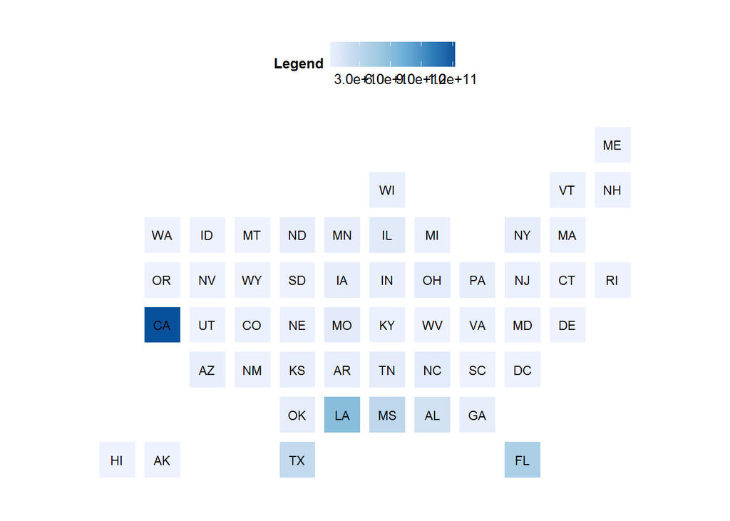

```r
psts <- group_by(ponly, STATE)
psts <- summarize(psts, count=n(), TPD=sum(pvalue))
psts.pure <- psts[psts$STATE %in% abvs,]
psts.pure$STATE <- as.character(psts.pure$STATE)
statebins_continuous(as.data.frame(psts.pure), brewer_pal="Blues",
                     state_col = "STATE", value_col = "TPD")
```

```r
arrange(psts.pure, desc(TPD))[1:10,]
```

```
## Source: local data frame [10 x 3]
##
##    STATE count          TPD
## 1     CA  2744 123587807663
## 2     LA  6091  60073505690
## 3     FL  7538  41510227973
## 4     MS 11799  29810132172
## 5     TX 20468  26641568619
## 6     AL 10810  17241461910
## 7     IL  5904   8536894692
## 8     NC  4818   8229595031
## 9     MO  6374   7179232438
## 10    OH 13040   6856088833
```